# Quick evaluation Miguel scores, round 3

### Synopsis

Evaluation of the third round of scoring Miguel Vázquez did for the DSP.

#### Libraries

```r
dyn.load('/Library/Java/JavaVirtualMachines/jdk1.8.0_131.jdk/Contents/Home/jre/lib/server/libjvm.dylib')
library(rJava)
require(data.table)
require(ggplot2)
require(xlsx)
require(gridExtra)
require(splitstackshape)
```

### Upload data

```r
dsp_scored_rd1 <- unique(fread("../round1/DarkSpace-v1.txt",sep="\t",header=T,skip=1))
dsp_scored_rd2 <- unique(data.table(read.xlsx2("../round2/DarkSpace_rank2.xls",sheetIndex=1,header=T,colClasses = c("character","numeric","character","integer","character","numeric","numeric"))))
dsp_scored_rd3 <- unique(fread("./pmid_ranks.txt",header=T))
```

### Preformat latest evaluation

```r
colnames(dsp_scored_rd3) <- tolower(gsub("-| ","_",colnames(dsp_scored_rd3)))
colnames(dsp_scored_rd3) <- tolower(gsub("#|\\(|\\)","",colnames(dsp_scored_rd3)))

dsp_scored_rd3 <- dsp_scored_rd3[,known:=ifelse(known_pairs=="",
                                                "false",
                                                "true")]
table(dsp_scored_rd3$known,useNA = "ifany")
```

[output not shown]

### Explore data

I check the distribution of the relevance and the combined score separating IMEx positive and negative publications and comparing the previous iterations with the current one.

#### Relevance score plot

```r
g1 <- ggplot(dsp_scored_rd1,aes(x=Relevance,fill=IMEX))
g1 <- g1 + geom_histogram(alpha=0.8,position='identity')
g1 <- g1 + xlab("relevance score")
g1 <- g1 + ylab("Number of publications")
g1 <- g1 + ggtitle("Relevance score distribution, round 1")
#g1 <- g1 + xlim(0.0,2.0)
g1 <- g1 + theme(plot.title = element_text(),
               panel.grid.major = element_blank(),
               panel.grid.minor = element_blank(),
               panel.background = element_blank())

g2 <- ggplot(dsp_scored_rd2,aes(x=Relevance,fill=IMEX))
g2 <- g2 + geom_histogram(alpha=0.8,position='identity')
g2 <- g2 + xlab("relevance score")
g2 <- g2 + ylab("Number of publications")
g2 <- g2 + ggtitle("Relevance score distribution, round 2")
#g2 <- g2 + xlim(0.0,2.0)
g2 <- g2 + theme(plot.title = element_text(),
               panel.grid.major = element_blank(),
               panel.grid.minor = element_blank(),
               panel.background = element_blank())

g3 <- ggplot(dsp_scored_rd3,aes(x=relevance,fill=known))
g3 <- g3 + geom_histogram(alpha=0.8,position='identity')
g3 <- g3 + xlab("relevance score")
g3 <- g3 + ylab("Number of publications")
g3 <- g3 + ggtitle("Relevance score distribution, round 3")
g3 <- g3 + scale_x_continuous(breaks=c(0:24))
g3 <- g3 + theme(plot.title = element_text(),
               panel.grid.major = element_blank(),
               panel.grid.minor = element_blank(),
               panel.background = element_blank())

grid.arrange(g1, g2, g3, ncol=1)
```

[output not shown]

```r
g1.1 <- ggplot(dsp_scored_rd1,aes(x=Relevance,fill=IMEX))
g1.1 <- g1.1 + geom_density(alpha=0.8,position='identity')
g1.1 <- g1.1 + xlab("relevance score")
g1.1 <- g1.1 + ylab("Number of publications")
g1.1 <- g1.1 + ggtitle("Relevance score distribution, round 1")
#g1.1 <- g1.1 + xlim(0.0,2.0)
g1.1 <- g1.1 + ylim(0,5)
g1.1 <- g1.1 + theme(plot.title = element_text(),
               panel.grid.major = element_blank(),
               panel.grid.minor = element_blank(),
               panel.background = element_blank())

g2.1 <- ggplot(dsp_scored_rd2,aes(x=Relevance,fill=IMEX))
g2.1 <- g2.1 + geom_density(alpha=0.8,position='identity')
g2.1 <- g2.1 + xlab("relevance score")
g2.1 <- g2.1 + ylab("Number of publications")
g2.1 <- g2.1 + ggtitle("Relevance score distribution, round 2")
#g2.1 <- g2.1 + xlim(0.0,2.0)
g2.1 <- g2.1 + ylim(0,5)
g2.1 <- g2.1 + theme(plot.title = element_text(),
               panel.grid.major = element_blank(),
               panel.grid.minor = element_blank(),
               panel.background = element_blank())

g3.1 <- ggplot(dsp_scored_rd3,aes(x=relevance,fill=known))
g3.1 <- g3.1 + geom_density(alpha=0.8,position='identity')
g3.1 <- g3.1 + xlab("relevance score")
g3.1 <- g3.1 + ylab("Number of publications")
g3.1 <- g3.1 + ggtitle("Relevance score distribution, round 3")
g3.1 <- g3.1 + scale_x_continuous(breaks=c(0:24))
g3.1 <- g3.1 + theme(plot.title = element_text(),
               panel.grid.major = element_blank(),
               panel.grid.minor = element_blank(),
               panel.background = element_blank())

grid.arrange(g1.1, g2.1, g3.1, ncol=1)
```

[output not shown]

#### Explore manually evaluated subset

Manual evaluation of 90 scored papers can be found in the file ‘eval_miguel_rd3.xlsx’. From an initial overview it seems the score does not perform as nicely as in previous implementations.

I have a closer look, taking into account the origin of the data and comparing with previous version of the score.

##### Upload manual evaluation

```r
manual <- fread("./manual.txt",header = T)
manual$pmid <- as.character(manual$pmid)
manual$id <- manual[,.(.I)]
```

##### Obtain DSP comparison table for reference

I will take the table that does the comparison at the publication level only for this comparison.

```r
if(!exists("dsp_pubcomp")){
        setwd("~/Documents/Projects/dsp/darkspaceproject/dsp_comparison/results/")
        dsp_pubcompNames = fread('cat pubcomp_table_final.txt.gz | gunzip | head -n 1')[, colnames(.SD)]
        dsp_pubcomp = fread('cat pubcomp_table_final.txt.gz | gunzip | grep -v "^Day"')
        setnames(dsp_pubcomp, dsp_pubcompNames)
        setwd("~/Documents/Projects/dsp/DarkSpace/manual_evaluation/round2/")
}
```

##### Merge origin into manual evaluation

```r
manual_ori <- data.table(unique(merge(manual,dsp_pubcomp,by="pmid",all.x=T,all.y=F)))
manual_ori <- manual_ori[order(id)]
fwrite(manual_ori,"./manual_ori.txt",col.names = T,row.names = F,quote=F,sep="\t")
```

##### Plot manual evaluation

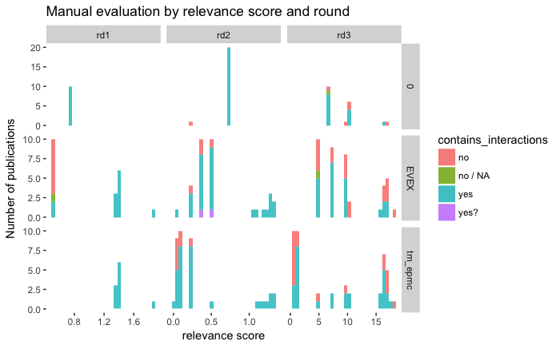

Numbers are to low to draw final conclusions, but it seems that the third round of the relevance score does not distinguish between papers containing interaction data as cleanly as in previous cases.

This could be caused by the change in criteria in terms of what is considered to be known or not. Rounds 1 and 2 only took into account IMEx data, round 3 takes BioGRID & GO into the mix.